# Difference in Diffferences

Paul Schrimpf

2025-11-17

# Difference in Differences

$$\def\Er{{\mathrm{E}}}
\def\En{{\mathbb{E}_n}}
\def\cov{{\mathrm{Cov}}}
\def\var{{\mathrm{Var}}}
\def\R{{\mathbb{R}}}
\newcommand\norm[1]{\left\lVert#1\right\rVert}
\def\rank{{\mathrm{rank}}}
\newcommand{\inpr}{ \overset{p^*_{\scriptscriptstyle n}}{\longrightarrow}}
\def\inprob{{\,{\buildrel p \over \rightarrow}\,}}
\def\indist{\,{\buildrel d \over \rightarrow}\,}
\DeclareMathOperator*{\plim}{plim}$$

## Setup

- Two periods, binary treatment in second period
- Potential outcomes $\{y_{it}(0),y_{it}(1)\}_{t=0}^1$ for $i=1,...,N$
- Treatment $D_{it} \in \{0,1\}$,
  - $D_{i0} = 0$ $\forall i$
  - $D_{i1} = 1$ for some, $0$ for others
- Observe $y_{it} = y_{it}(0)(1-D_{it}) + D_{it} y_{it}(1)$

## Identification

- Average treatment effect on the treated:
  $$\begin{align*}
  ATT & = \Er[y_{i1}(1) - \color{red}{y_{i1}(0)} | D_{i1} = 1] \\
  & = \Er[y_{i1}(1) - y_{i0}(0) | D_{i1} = 1] - \Er[\color{red}{y_{i1}(0)} - y_{i0}(0) | D_{i1}=1] \\
  & \text{ assume } \Er[\color{red}{y_{i1}(0)} - y_{i0}(0) | D_{i1}=1] = \Er[y_{i1}(0) - y_{i0}(0) | D_{i1}=0] \\
  & = \Er[y_{i1}(1) - y_{i0}(0) | D_{i1} = 1] - \Er[y_{i1}(0) - y_{i0}(0) | D_{i1}=0] \\
  & = \Er[y_{i1} - y_{i0} | D_{i1}=1, D_{i0}=0] - \Er[y_{i1} - y_{i0} | D_{i1}=0, D_{i0}=0]
  \end{align*}$$

## Important Assumptions

- No anticipation: $D_{i1}=1$ does not affect $y_{i0}$
  - built into the potential outcomes notation we used
  - relaxing would be allowing potential outcomes to depend on sequence of $D$ – $y_{it}(D_{i0},D_{i1})$ (would require different estimator and assumptions)
- Parallel trends: $\Er[\color{red}{y_{i1}(0)} - y_{i0}(0) |D_{i1}=1,D_{i0}=0] = \Er[y_{i1}(0) - y_{i0}(0) | D_{i1}=0], D_{i0}=0]$
  - not invariant to tranformations of $y$

## Parallel Trends in Levels

```julia
using DataFrames, Statistics, Measures
import Plots

# Parameters
n_periods = 10
group_names = ["Control", "Treatment"]
initials = [10.0, 5.0]
trend = 1

data = DataFrame(group=String[], time=Int[], y=Float64[])
for (g, initial) in enumerate(initials)
    y = initial
    for t in 1:n_periods
        push!(data, (group_names[g], t, y))
        y = initial + trend * t
    end
end

data.log_y = log.(data.y)

# Compute growth rates (difference in logs)
data.growth_rate = vcat(missing, diff(data.log_y))
sameid = vcat(true, data.group[1:(end-1)] .== data.group[2:end])
data.growth_rate[.!sameid] .= missing

# Plot growth rates
function plot_trends(data)
    plt1 = Plots.plot(title="Levels", xlabel="Time", ylabel="y");
    for g in group_names
        idx = data.group .== g
        Plots.plot!(plt1, data.time[idx], data.y[idx], label=g, marker=:circle);
    end

    plt2 = Plots.plot(title="Logs", xlabel="Time", ylabel="log(y)");
    for g in group_names
        idx = data.group .== g
        Plots.plot!(plt2, data.time[idx], data.log_y[idx], label=g, marker=:circle);
    end

    plt3 = Plots.plot(title="Growth Rates", xlabel="Time", ylabel="Δlog(y)");
    for g in group_names
        idx = (data.group .== g) .& (.!ismissing.(data.growth_rate))
        Plots.plot!(plt3, data.time[idx], data.growth_rate[idx], label=g, marker=:circle);
        if -(-)(extrema(skipmissing(data.growth_rate))...) < 1e-4
            Plots.ylims!(plt3, mean(skipmissing(data.growth_rate)) .+ (-0.01, 0.01))
        end
    end

    Plots.plot(plt1, plt2, plt3, layout=(1,3), size=(900,300), margin=5mm)
end
plot_trends(data)
```

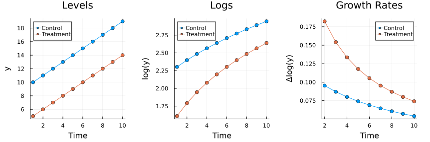

## Parallel Trends in Logs

```julia
using DataFrames
import Plots

# Parameters
n_periods = 10
group_names = ["Control", "Treatment"]
initials = [5.0, 6.0]
trend = -0.1

data = DataFrame(group=String[], time=Int[], log_y=Float64[])
for (g, initial) in enumerate(initials)
    log_y = initial
    for t in 1:n_periods
        push!(data, (group_names[g], t, log_y))
        log_y = initial + t*trend
    end
end

data.y = exp.(data.log_y)

# Compute growth rates (difference in logs)
data.growth_rate = vcat(missing, diff(data.log_y))
sameid = vcat(true, data.group[1:(end-1)] .== data.group[2:end])
data.growth_rate[.!sameid] .= missing

plot_trends(data)
```

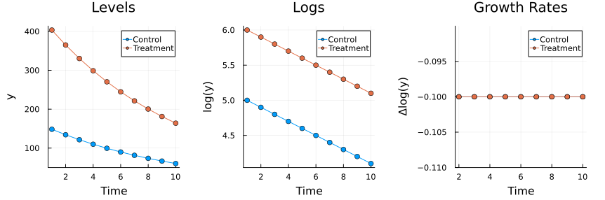

## Parallel Trends in Growth Rates

```julia
using DataFrames
import Plots

# Parameters
n_periods = 10
group_names = ["Control", "Treatment"]
initials = [20.0, 19.0]
growth = [1.10, 1.07]
growth_trend = -0.004

data = DataFrame(group=String[], time=Int[], y=Float64[])
for (g, initial) in enumerate(initials)
    y = initial
    for t in 0:n_periods-1
        push!(data, (group_names[g], t, y))
        y *= growth[g] + growth_trend * t
    end
end

data.log_y = log.(data.y)

# Compute growth rates (difference in logs)
data.growth_rate = vcat(missing, diff(data.log_y))
sameid = vcat(true, data.group[1:(end-1)] .== data.group[2:end])
data.growth_rate[.!sameid] .= missing

plot_trends(data)
```

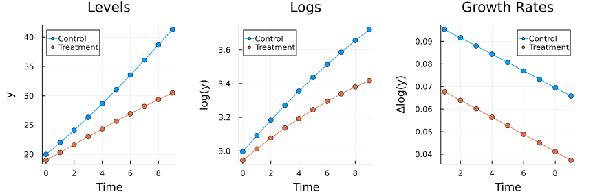

## Estimation

- Plugin:
  $$\widehat{ATT} = \frac{ \sum_{i=1}^n (y_{i1} - y_{i0})D_{i1}(1-D_{i0})}{\sum_{i=1}^n D_{i1}(1-D_{i0})} - \frac{ \sum_{i=1}^n (y_{i1} - y_{i0})(1-D_{i1})(1-D_{i0})}{\sum_{i=1}^n (1-D_{i1})(1-D_{i0})}$$
- Regression:
  $$y_{it} = \delta_t + \alpha 1\{D_{i1}=1\} + \beta D_{it} + \epsilon_{it}$$
  then $\hat{\beta} = \widehat{ATT}$
- Fixed effects:
  $$y_{it} = \delta_t + \alpha_i + \beta D_{it} + u_{it}$$
  then $\hat{\beta} = \widehat{ATT}$

# Multiple Periods

## Identification

- Same logic as before,
  $$\begin{align*}
  ATT_{t,t-s} & = \Er[y_{it}(1) - \color{red}{y_{it}(0)} | D_{it} = 1, D_{it-s}=0] \\
  & = \Er[y_{it}(1) - y_{it-s}(0) | D_{it} = 1, D_{it-s}=0] - \\
  & \;\; - \Er[\color{red}{y_{it}(0)} - y_{t-s}(0) | D_{it}=1, D_{it-s}=0]
  \end{align*}$$
  - assume $\Er[\color{red}{y_{it}(0)} - y_{it-s}(0) | D_{it}=1, D_{it-s}=0] = \Er[y_{it}(0) - y_{it-s}(0) | D_{it}=0, D_{it-s}=0]$

$$\begin{align*}
ATT_{t,t-s}& = \Er[y_{it} - y_{it-s} | D_{it}=1, D_{it-s}=0] - \Er[y_{it} - y_{it-s} | D_{it}=0, D_{it-s}=0]
\end{align*}$$
- Similarly, can identify various other interpretable average treatment effects conditional on being treated at some times and not others

## Estimation

- Plugin
- Fixed effects?
  $$y_{it} = \beta D_{it} + \alpha_i + \delta_t + \epsilon_{it}$$
  When will $\hat{\beta}^{FE}$ consistently estimate some interpretable conditional average of treatment effects?

## Fixed Effects

- As on problem set 6,
  $$\begin{align*}
  \hat{\beta} = & \sum_{i=1,t=1}^{n,T} y_{it} \overbrace{\frac{\tilde{D}_{it}}{ \sum_{i,t} \tilde{D}_{it}^2 }}^{\hat{\omega}_{it}(D_it)} \\
  = & \sum_{i=1,t=1}^{n,T} y_{it}(0) \hat{\omega}_{it}(D_it) + \sum_{i=1,t=1}^{n,T} D_{it} (y_{it}(1) - y_{it}(0)) \hat{\omega}_{it}(D_it)
  \end{align*}$$
  where
  $$\begin{align*}
  \tilde{D}_{it} & = D_{it} - \frac{1}{n} \sum_{j=1}^n (D_{jt} - \frac{1}{T} \sum_{s=1}^T D_{js}) - \frac{1}{T} \sum_{s=1}^T D_{is} \\
  & = D_{it} - \frac{1}{n} \sum_{j=1}^n D_{jt} - \frac{1}{T} \sum_{s=1}^T D_{is} + \frac{1}{nT} \sum_{j,s} D_{js}
  \end{align*}$$

## Simulation

- $T$ periods
- Once $i$ treated, remains treated

## Weights

```julia
using Statistics
function assigntreat(n,T;portiontreated=vcat(zeros(T ÷ 2), 0.5, zeros(T - (T ÷ 2) - 1)))
  treated = falses(n,T)
  for t=2:T
    treated[:,t] = treated[:,t-1]
    if (portiontreated[t]>0)
      treated[:,t] = (treated[:,t] .|| rand(n) .< portiontreated[t])
    end
  end
  return(treated)
end

function weights(D)
  D̃ = D .- mean(D,dims=1) .- mean(D,dims=2) .+ mean(D)
  ω = D̃./sum(D̃.^2)
end

n = 500
T = 9
D = assigntreat(n,T)
y = randn(n,T)
sum(y.*weights(D))
```

```
-0.09751866808826863
```

```julia
n,T = size(D)
using DataFrames, FixedEffectModels, RegressionTables
df = DataFrame(id = vec((1:n)*ones(Int,T)'), t = vec(ones(Int,n)*(1:T)'), y = vec(y), D=vec(D))
m=reg(df, @formula(y ~ D + fe(t) + fe(id)))
regtable(m, render=AsciiTable())
```

```
--------------------------
                      y
--------------------------
D                   -0.098
                   (0.061)
--------------------------
t Fixed Effects        Yes
id Fixed Effects       Yes
--------------------------
N                    4,500
R2                   0.113
Within-R2            0.001
--------------------------
```

## Portion Treated with Single Treatment Time

```julia
using PlotlyLight

function plotp(D; width=900, height=300)
  n,T=size(D)
  plt=Plot()
  plt.layout=Config(xaxis=Config(title=Config(text="time"),tickvals=1:T),
                    yaxis=Config(title=Config(text="Portion Treated")),
                    autosize=false,
                    width=width,
                    height=height)
  plt(x=1:T,y=vec(mean(D,dims=1)))
  plt()
end

pfig = plotp(D)
pfig
```

## Weights with Single Treatment Time

```julia
import StatsPlots
function plotweights(D; width=900, height=300)
    n,T = size(D)
    ω = weights(D)
    groups = unique(eachrow(D))
    plt = Plot()
    plt.layout=Config(xaxis=Config(title=Config(text="time"),tickvals=1:T),
                      yaxis=Config(title=Config(text="weight")),
                      autosize=false,
                      width=width,
                      height=height)

    for g in groups
        i = findfirst(d == g for d in eachrow(D))
        wt = ω[i,:]
        plt(x=1:T,y=wt,name="Treated $(sum(g)) times", mode="markers",type="scatter")
    end
    fig=plt()

    evertreated = any(D, dims=2)*ones(Int,1,size(D,2)).==1
    aftertreatment = ones(Int,size(D,1))*any(D,dims=1).==1
    g=[(et ? "Treated," : "Control,") * (at ? "After" : "Before") for (et,at) in zip(evertreated, aftertreatment)]
    histo = StatsPlots.groupedhist(vec(ω),group=vec(g),
                                   title="Histogram of Weights",
                                   xlabel="Weight", ylabel="Frequency",
                                   bins=min(length(unique(ω)),20),
                                   size=(900,300), margin=5mm)
    Plots.vline!(histo, [0.0], line=(:black, :dash),label=:none, width=4)

    return(fig, histo)
end
fig,histo = plotweights(D)
fig
```

## Weight Distribution with Single Treatment Time

```julia
histo
```

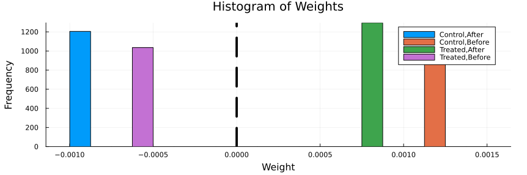

## Portion Treated with Uniform Treatment Time

```julia
D = assigntreat(n,T,portiontreated=vcat(0,fill(0.5/(T-1),T-1)))
pfig = plotp(D)
pfig
```

## Weights with Uniform Treatment Time

```julia
fig,histo = plotweights(D)
fig
```

## Distribution of Weights with Uniform Treatment Time

```julia
histo
```

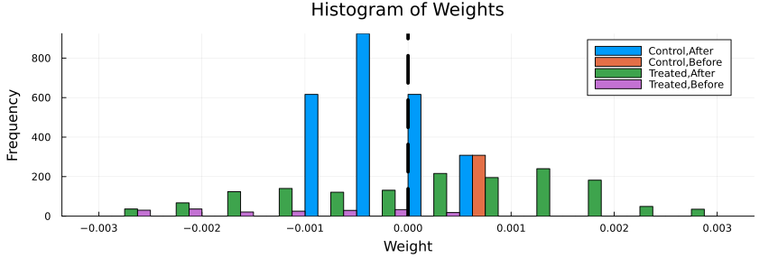

## Portion Treated with Early and Late Treated

```julia
pt = zeros(T)
pt[2] = 1/3
pt[end-1]=1/3
D = assigntreat(n,T,portiontreated=pt)
pfig = plotp(D)
pfig
```

## Weights with Early and Late Treated

```julia
fig,histo = plotweights(D)
fig
```

## Distribution of Weights with Early and Late Treated

```julia
histo
```

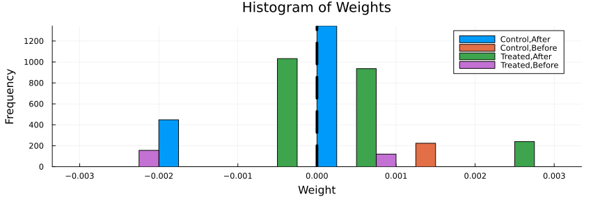

## Sign Reversal with Fixed Effects

- True Treatment Effects

```julia
pt = zeros(T)
pt[2] = 1/3
pt[end-1]=1/3

function simulate(n,T,portiontreated, ATT, σ=0.25)
  D = assigntreat(n,T,portiontreated=portiontreated)
  y = randn(n,T)*σ
  for i in axes(y)[1]
    timetreated=cumsum(D[i,:])
    y[i,:] .+= (tt>0 ? ATT[tt] : 0.0 for tt in timetreated)
  end
  DataFrame(id = vec((1:n)*ones(Int,T)'), t = vec(ones(Int,n)*(1:T)'), y = vec(y), D=vec(D))
end

ATT =  vcat(ones(T-3),10*ones(3))
df = simulate(n,T, pt,ATT,1.0)

function plotGAT(ATT,D; width=900, height=300)
  n,T = size(D)
  groups = unique(eachrow(D))
  plt = Plot()
  plt.layout=Config(xaxis=Config(title="time",tickvals=1:T),
                    yaxis=Config(title="ATT"),
                    autosize=false,
                    width=width,
                    height=height)

  for g in groups
    t = findfirst(g)
    if (isnothing(t))
      t=T+1
    end
    ate = vcat(zeros(t-1), ATT[1:(T-t+1)])
    plt(x=1:T,y=ate,name="Treated $(sum(g)) times", mode="markers",type="scatter")
    end
  fig=plt()
  return(fig)
end

plotGAT(ATT,D)
```

## Sign Reversal with Fixed Effects

- Fixed Effects Estimate

```julia
m=reg(df, @formula(y ~ D + fe(t) + fe(id)))
regtable(m, render=AsciiTable())
```

```
---------------------------
                       y
---------------------------
D                  -0.431**
                    (0.144)
---------------------------
t Fixed Effects         Yes
id Fixed Effects        Yes
---------------------------
N                     4,500
R2                    0.497
Within-R2             0.002
---------------------------
```

## When to worry

- If multiple treatment times and treatment heterogeneity
- Even if weights do not have wrong sign, the fixed effects estimate is hard to interpret
- Same logic applies more generally – not just to time
  - E.g. if have group effects, some treated units in multiple groups, and $E[y(1) - y(0) | group]$ varies

# What to Do?

## Plug-in Estimator

- Follow identification
  $$\begin{align*}
  ATT_{t,t-s}& = \Er[y_{it} - y_{it-s} | D_{it}=1, D_{it-s}=0] - \Er[y_{it} - y_{it-s} | D_{it}=0, D_{it-s}=0]
  \end{align*}$$
  and estimate
  $$\begin{align*}
  \widehat{ATT}_{t,t-s} = & \frac{\sum_i y_{it} D_{it}(1-D_{it-s})}{\sum_i D_{it}(1-D_{it-s})} \\
  & - \frac{\sum_i y_{it} (1-D_{it})(1-D_{it-s})}{\sum_i (1-D_{it})(1-D_{it-s})}
  \end{align*}$$
  and perhaps some average, e.g. (there are other reasonable weighted averages)
  $$\sum_{t=1}^T \frac{\sum_i D_{it}}{\sum_{i,s} D_{i,s}} \frac{1}{t-1} \sum_{s=1}^{t-1} \widehat{ATT}_{t,t-s}$$
  - Inference? Optimal?

## What to Do? Flexibly Model Conditional Expectation

- Problem is possible correlation of $(y_{it}(1) - y_{it}(0))D_{it}$ with $\tilde{D}_{it}$
  - $\tilde{D}_{it}$ is function of $t$ and $(D_{i1}, ..., D_{iT})$
  - Estimating separate coefficient for each combination of $t$ and $(D_{i1}, ..., D_{iT})$ will eliminate correlation / flexibly model treatment effect heterogeneity

## Cohorts

- Cohorts = unique sequences of $(D_{i1}, ..., D_{iT})$
  - In last simulated example, three cohorts
    1. $(0, 0, 0, 0, 0, 0, 0, 0, 0)$
    2. $(0, 0, 0, 0, 0, 0, 0, 1, 1)$
    3. $(0, 1, 1, 1, 1, 1, 1, 1, 1)$
- Flexible conditional expectation
  $$\Er[y_{it}|t, D_{i1}=d_1, ..., D_{iT}=d_T] = \sum{c, s} \beta_{c,s} \mathbbm{1}\{cohort(i)=c,s=t\}$$

```julia
using CategoricalArrays

function createCohorts(df)
  n = length(unique(df.id))
  T = length(unique(df.t))
  sorted = sort(df, [:id, :t])
  D = reshape(sorted.D, T,n)'
  groups = sort(unique(eachrow(D)))
  cohorts = [findfirst(d == g for g in groups) for d in eachrow(D)]
  df=leftjoin(sorted, DataFrame(cohort=categorical(cohorts), id=unique(sorted.id)), on=:id)
  df.DCt .= "untreated"
  for r in 1:T
    for c in unique(df.cohort)
      dct = (df.t .== r) .& (df.cohort .== c) .& df.D
      if (any(dct))
        df.DCt[dct] .= "c$(c),t$(r)"
        df[!,"Dc$(c)t$(r)"] .= false
        df[!,"Dc$(c)t$(r)"][dct] .= true
      end
    end
  end
  df.ct = categorical(df.t)
  df
end

dfc = createCohorts(df);
```

## Regression with Cohort Interactions

```julia
m=reg(dfc, @formula(y ~ -1 + cohort&ct), Vcov.cluster(:id))
regtable(m, render=AsciiTable())
```

```
-----------------------------
                        y
-----------------------------
cohort: 1 & ct: 1       0.031
                      (0.067)
cohort: 2 & ct: 1      -0.120
                      (0.093)
cohort: 3 & ct: 1       0.008
                      (0.080)
cohort: 1 & ct: 2      -0.045
                      (0.070)
cohort: 2 & ct: 2      -0.087
                      (0.100)
cohort: 3 & ct: 2    1.110***
                      (0.074)
cohort: 1 & ct: 3       0.005
                      (0.071)
cohort: 2 & ct: 3       0.014
                      (0.090)
cohort: 3 & ct: 3    0.910***
                      (0.068)
cohort: 1 & ct: 4       0.031
                      (0.069)
cohort: 2 & ct: 4      -0.030
                      (0.099)
cohort: 3 & ct: 4    1.013***
                      (0.076)
cohort: 1 & ct: 5       0.040
                      (0.070)
cohort: 2 & ct: 5      -0.015
                      (0.100)
cohort: 3 & ct: 5    0.998***
                      (0.079)
cohort: 1 & ct: 6      -0.001
                      (0.069)
cohort: 2 & ct: 6      -0.012
                      (0.097)
cohort: 3 & ct: 6    0.977***
                      (0.074)
cohort: 1 & ct: 7      -0.034
                      (0.072)
cohort: 2 & ct: 7       0.141
                      (0.099)
cohort: 3 & ct: 7    0.940***
                      (0.078)
cohort: 1 & ct: 8      -0.022
                      (0.065)
cohort: 2 & ct: 8    0.881***
                      (0.102)
cohort: 3 & ct: 8    9.991***
                      (0.079)
cohort: 1 & ct: 9       0.019
                      (0.069)
cohort: 2 & ct: 9    1.163***
                      (0.083)
cohort: 3 & ct: 9   10.105***
                      (0.076)
-----------------------------
N                       4,500
R2                      0.888
-----------------------------
```

## Regression with Cohort Interactions: $\hat{\Er}[y|\mathrm{cohort}, t]$

```julia
using Plots, LinearAlgebra
function plotEy(m)
    rms = match.(r"cohort: (\d+) & ct: (\d+)", coefnames(m))
    ct = [parse.(Int, r.captures) for r in rms]
    cohort = [c[1] for c in ct]
    time = [c[2] for c in ct]
    ey = coef(m)
    se = sqrt.(diag(vcov(m)))
    fig=Plots.plot(time, ey, ribbon=1.96*se, group=cohort, xlabel="time", ylabel="E[y|cohort,t]", legend=:topleft)
end
plotEy(m)
```

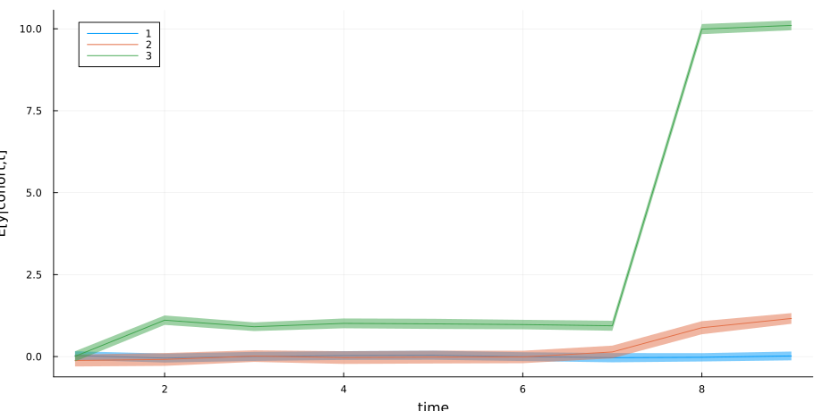

## Differences in which Difference?

- Time:
  - For cohort 3, only one untreated period, so only possible difference across time is $t$ versus $1$
  - For cohort 2, many differences across time possible because many untreated periods
  - Typical to report differences between $t$ and last period before treatment in “event study” figure
- Groups:
  - For ATT for cohort 3 at time 2, should cohort 1 or cohort 2 or both be used a controls?

## Event Study

```julia
function ploteventstudy(m,dfc)
    rms = match.(r"cohort: (\d+) & ct: (\d+)", coefnames(m))
    ct = [parse.(Int, r.captures) for r in rms]
    cohort = [c[1] for c in ct]
    time = [c[2] for c in ct]
    ey = coef(m)
    ttdf = combine(groupby(dfc,:cohort),[:t,:D] => ((t,d)->(any(d) ? minimum(t[d]) : missing)) => :treattime)
    ttdict = Dict(ttdf.cohort .=> ttdf.treattime)
    treattime= [ttdict[c] for c in cohort]
    rtt = time .- treattime
    controlgroup = cohort[ismissing.(treattime)][1]
    ATT = zeros(length(ey))
    se = zeros(length(ey))
    for (i,(c,t)) in enumerate(zip(cohort, time))
        if c == controlgroup
            continue
        end
        baset = ttdict[c] - 1
        DiD = 1*((cohort .== c) .& (time .== t)) - 1*((cohort .== controlgroup) .& (time .== t)) -
            1*((cohort .== c) .& (time .== baset)) + 1*((cohort .== controlgroup) .& (time .== baset))
        ATT[i] = DiD'*ey
        se[i] = sqrt(DiD'*vcov(m)*DiD)
    end
    rtt = rtt[cohort.!=controlgroup]
    se = se[cohort.!=controlgroup]
    ATT = ATT[cohort.!=controlgroup]
    fig=Plots.plot(rtt, ATT, ribbon=1.96*se, xlabel="time relative to treatment", ylabel="E[y_t-y_{-1}|cohort]-E[y_t-y_{-1}|nevertreated] ", group=cohort[cohort.!=controlgroup], legend=true)
end
ploteventstudy(m,dfc)
```

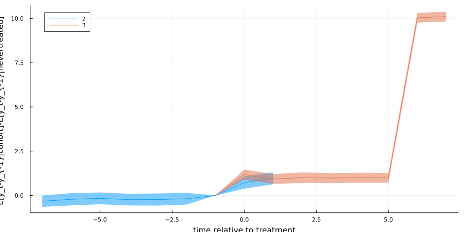

## Regression with Cohort Interactions

```julia
m=reg(dfc, @formula(y ~ DCt + fe(id) + fe(t)), Vcov.cluster(:id), contrasts=Dict(:DCt=>DummyCoding(base="untreated")))
regtable(m, render=AsciiTable())
```

```
----------------------------
                       y
----------------------------
DCt: c2,t8          0.923***
                     (0.135)
DCt: c2,t9          1.164***
                     (0.118)
DCt: c3,t2          1.140***
                     (0.133)
DCt: c3,t3          0.873***
                     (0.127)
DCt: c3,t4          0.974***
                     (0.143)
DCt: c3,t5          0.948***
                     (0.135)
DCt: c3,t6          0.953***
                     (0.132)
DCt: c3,t7          0.885***
                     (0.129)
DCt: c3,t8          9.992***
                     (0.137)
DCt: c3,t9         10.063***
                     (0.139)
----------------------------
id Fixed Effects         Yes
t Fixed Effects          Yes
----------------------------
N                      4,500
R2                     0.887
Within-R2              0.776
----------------------------
```

## What to Do?

- Understand existing methods: read reviews Chaisemartin and D’Haultfœuille (2022), Roth et al. (2023), Chaisemartin and D’Haultfœuille (2023), Wing et al. (2024)
- Use an appropriate package:
  - partial list on https://asjadnaqvi.github.io/DiD/

# Pre-trends

## Pre-trends

- Parallel trends assumption

$$\Er[\color{red}{y_{it}(0)} - y_{it-s}(0) | D_{it}=1, D_{it-s}=0] = \Er[y_{it}(0) - y_{it-s}(0) | D_{it}=0, D_{it-s}=0]$$

- More plausible if there are parallel pre-trends

$$\begin{align*}
& \Er[y_{it-r}(0) - y_{it-s}(0) | D_{it}=1, D_{it-r}=0, D_{it-s}=0] = \\
& = \Er[y_{it-r}(0) - y_{it-s}(0) | D_{it}=0, D_{it-r}=0, D_{it-s}=0]
\end{align*}$$

- Always at least plot pre-trends

## Testing for Pre-trends

- Is it a good idea to test

$$\begin{align*}
H_0 : & \Er[y_{it-r} - y_{it-s} | D_{it}=1, D_{it-r}=0, D_{it-s}=0] = \\
& = \Er[y_{it-r} - y_{it-s} | D_{it}=0, D_{it-r}=0, D_{it-s}=0]?
\end{align*}$$
- Even if not testing formally, we do it informally by plotting

## Testing for Pre-trends

- Assume: $(y_{i1}, ..., y_{iT}, D_{i1},..., D_{iT})$ i.i.d. across $i$ with finite second moments
- Let
  $$\tau^{1t}_{r,s} = \Er[y_{ir}|D_{it}=1, D_{ir}=0, D_{is}=0]$$
  $$\tau^{0t}_{r,s} = \Er[y_{ir}|D_{it}=0, D_{ir}=0, D_{is}=0]$$
- Plugin estimators
  $$\hat{\tau}^{1t}_{r,s} = \frac{\sum_i y_{ir} D_{it}(1-D_{ir})(1-D_{is})} {\sum_i D_{it}(1-D_{ir})(1-D_{is})}$$
  $$\hat{\tau}^{0t}_{r,s} = \frac{\sum_i y_{ir} (1-D_{it})(1-D_{ir})(1-D_{is})} {\sum_i (1-D_{it})(1-D_{ir})(1-D_{is})}$$

## Testing for Pre-trends

- Note:
  $$\begin{align*}
  \hat{\tau}^{1t}_{r,s} - \tau^{1t}_{r,s} = & \frac{\frac{1}{n}\sum_i y_{ir} D_{it}(1-D_{ir})(1-D_{is}) - \Er[y_{ir} D_{it}(1-D_{ir})(1-D_{is})]}{\Er[D_{it}(1-D_{ir})(1-D_{is})]} + \\
  & + \frac{\Er[y_{it} D_{it}(1-D_{ir})(1-D_{is})]}{\Er[D_{it}(1-D_{ir})(1-D_{is})]^2} \left(\frac{1}{n} \sum_i D_{it}(1-D_{ir})(1-D_{is}) - \Er[D_{it}(1-D_{ir})(1-D_{is})] \right)
  \end{align*}$$
  and similar expression for $\hat{\tau}^{0t}_{r,s}$
- Use CLT to get joint asymptotic distribution of pre-trends and $ATT_{t,t-s}$

## Testing for Pre-trends

- E.g. $T=3$, $D_{i3}=1$ for some $i$, other $D_{it}=0$
  $$\begin{align*}
  \sqrt{n} \left[
  \begin{pmatrix} \hat{\tau}^{13}_{2,1} - \hat{\tau}^{03}_{2,1} \\
  \underbrace{\hat{\tau}^{13}_{3,2} - \hat{\tau}^{03}_{3,2}}_{\widehat{ATT}_{3,2}}
  \end{pmatrix} -
  \begin{pmatrix}
  \tau^{13}_{2,1} - \tau^{03}_{2,1} \\
  ATT_{3,2}
  \end{pmatrix}
  \right] \indist N(0, \Sigma)
  \end{align*}$$
- Distribution of $\widehat{ATT}_{3,2}$ conditional on fail to reject $\tau^{13}_{2,1} - \tau^{03}_{2,1} = 0$ is a truncated normal
- Roth (2022) : test can have low power, and in plausible violations, $\widehat{ATT}_{3,2}$ conditional on failing to reject is biased

## Bounds from Pre-trends

- Let $\Delta$ be violation of parallel trends
  $$\Delta = \Er[\color{red}{y_{it}(0)} - y_{it-1}(0) | D_{it}=1, D_{it-1}=0] - \Er[y_{it}(0) - y_{it-1}(0) | D_{it}=0, D_{it-1}=0]$$
- Assume $\Delta$ is bounded by deviation from parallel of pre-trends
  $$|\Delta| \leq M \max_{r} \left\vert \tau^{1t}_{t-r,t-r-1} - \tau^{0t}_{t-r,t-r-1} \right\vert$$
  for some chosen $M$
- See Rambachan and Roth (2023)

## Reading

- Book: Chaisemartin and D’Haultfœuille (2023)
- Recent reviews: Roth et al. (2023), Chaisemartin and D’Haultfœuille (2022), Arkhangelsky and Imbens (2023), Wing et al. (2024)
- Early work pointing to problems with fixed effects:
  - Laporte and Windmeijer (2005), Wooldridge (2005)
- Explosion of papers written just before 2020, published just after:
  - Borusyak and Jaravel (2018)
  - Chaisemartin and D’Haultfœuille (2020)
  - Callaway and Sant’Anna (2021)
  - Goodman-Bacon (2021)
  - Sun and Abraham (2021)

## References

Arkhangelsky, Dmitry, and Guido Imbens. 2023. *Causal Models for Longitudinal and Panel Data: A Survey*.

Borusyak, Kirill, and Xavier Jaravel. 2018. *Revisiting Event Study Designs*. https://scholar.harvard.edu/files/borusyak/files/borusyak_jaravel_event_studies.pdf.

Callaway, Brantly, and Pedro H. C. Sant’Anna. 2021. “Difference-in-Differences with Multiple Time Periods.” *Journal of Econometrics* 225 (2): 200–230. https://doi.org/https://doi.org/10.1016/j.jeconom.2020.12.001.

Chaisemartin, C de, and X D’Haultfœuille. 2023. *Credible Answers to Hard Questions: Differences-in-Differences for Natural Experiments*. https://dx.doi.org/10.2139/ssrn.4487202.

Chaisemartin, Clément de, and Xavier D’Haultfœuille. 2020. “Two-Way Fixed Effects Estimators with Heterogeneous Treatment Effects.” *American Economic Review* 110 (9): 2964–96. https://doi.org/10.1257/aer.20181169.

Chaisemartin, Clément de, and Xavier D’Haultfœuille. 2022. “Two-way fixed effects and differences-in-differences with heterogeneous treatment effects: a survey.” *The Econometrics Journal* 26 (3): C1–30. https://doi.org/10.1093/ectj/utac017.

Goodman-Bacon, Andrew. 2021. “Difference-in-Differences with Variation in Treatment Timing.” *Journal of Econometrics* 225 (2): 254–77. https://doi.org/https://doi.org/10.1016/j.jeconom.2021.03.014.

Laporte, Audrey, and Frank Windmeijer. 2005. “Estimation of Panel Data Models with Binary Indicators When Treatment Effects Are Not Constant over Time.” *Economics Letters* 88 (3): 389–96. https://doi.org/https://doi.org/10.1016/j.econlet.2005.04.002.

Rambachan, Ashesh, and Jonathan Roth. 2023. “A More Credible Approach to Parallel Trends.” *The Review of Economic Studies* 90 (5): 2555–91. https://doi.org/10.1093/restud/rdad018.

Roth, Jonathan. 2022. “Pretest with Caution: Event-Study Estimates After Testing for Parallel Trends.” *American Economic Review: Insights* 4 (3): 305–22. https://doi.org/10.1257/aeri.20210236.

Roth, Jonathan, Pedro H. C. Sant’Anna, Alyssa Bilinski, and John Poe. 2023. “What’s Trending in Difference-in-Differences? A Synthesis of the Recent Econometrics Literature.” *Journal of Econometrics* 235 (2): 2218–44. https://doi.org/https://doi.org/10.1016/j.jeconom.2023.03.008.

Sun, Liyang, and Sarah Abraham. 2021. “Estimating Dynamic Treatment Effects in Event Studies with Heterogeneous Treatment Effects.” *Journal of Econometrics* 225 (2): 175–99. https://doi.org/https://doi.org/10.1016/j.jeconom.2020.09.006.

Wing, Coady, Madeline Yozwiak, Alex Hollingsworth, Seth Freedman, and Kosali Simon. 2024. “Designing Difference-in-Difference Studies with Staggered Treatment Adoption: Key Concepts and Practical Guidelines.” Journal Article. *Annual Review of Public Health* 45 (Volume 45, 2024): 485–505. https://doi.org/https://doi.org/10.1146/annurev-publhealth-061022-050825.

Wooldridge, Jeffrey M. 2005. “Fixed-Effects and Related Estimators for Correlated Random-Coefficient and Treatment-Effect Panel Data Models.” *The Review of Economics and Statistics* 87 (2): 385–90. https://doi.org/10.1162/0034653053970320.